# Telecom_Churn_Group_Case_Study

### 3. Random Forest

```python
from sklearn.model_selection import KFold
from sklearn.model_selection import GridSearchCV

parameters = {'max_depth': range(10, 30, 5)}
RFModel = RandomForestClassifier()
rfgs = GridSearchCV(RFModel, parameters,
                    cv=5,
                   scoring="f1", return_train_score=True)
rfgs.fit(X_train_pca,y_train_res)
```

```
GridSearchCV(cv=5, error_score=nan,
             estimator=RandomForestClassifier(bootstrap=True, ccp_alpha=0.0,
                                              class_weight=None,
                                              criterion='gini', max_depth=None,
                                              max_features='auto',
                                              max_leaf_nodes=None,
                                              max_samples=None,
                                              min_impurity_decrease=0.0,
                                              min_impurity_split=None,
                                              min_samples_leaf=1,
                                              min_samples_split=2,
                                              min_weight_fraction_leaf=0.0,
                                              n_estimators=100, n_jobs=None,
                                              oob_score=False,
                                              random_state=None, verbose=0,
                                              warm_start=False),
             iid='deprecated', n_jobs=None,
             param_grid={'max_depth': range(10, 30, 5)},
             pre_dispatch='2*n_jobs', refit=True, return_train_score=True,
             scoring='f1', verbose=0)
```

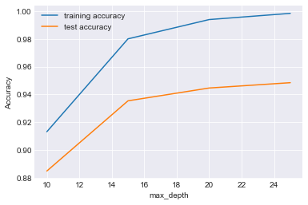

```python
# Tuning max_depth
scores = rfgs.cv_results_
# plotting accuracies with max_depth
plt.figure()
plt.plot(scores["param_max_depth"],
         scores["mean_train_score"],
         label="training accuracy")
plt.plot(scores["param_max_depth"],
         scores["mean_test_score"],
         label="test accuracy")
plt.xlabel("max_depth")
plt.ylabel("Accuracy")
plt.legend()
plt.show()
```

Test f1-score almost becomes constant after max_depth=20

```python
# Tuning n_estimators
parameters = {'n_estimators': range(50, 150, 25)}
rf1 = RandomForestClassifier(max_depth=20,random_state=10)
rfgs = GridSearchCV(rf1, parameters,
                    cv=3,
                   scoring="recall", return_train_score=True)
```

```python
rfgs.fit(X_train_pca,y_train_res)
```

```
GridSearchCV(cv=3, error_score=nan,
             estimator=RandomForestClassifier(bootstrap=True, ccp_alpha=0.0,
                                              class_weight=None,
                                              criterion='gini', max_depth=20,
                                              max_features='auto',
                                              max_leaf_nodes=None,
                                              max_samples=None,
                                              min_impurity_decrease=0.0,
                                              min_impurity_split=None,
                                              min_samples_leaf=1,
                                              min_samples_split=2,
                                              min_weight_fraction_leaf=0.0,
                                              n_estimators=100, n_jobs=None,
                                              oob_score=False, random_state=10,
                                              verbose=0, warm_start=False),
             iid='deprecated', n_jobs=None,
             param_grid={'n_estimators': range(50, 150, 25)},
             pre_dispatch='2*n_jobs', refit=True, return_train_score=True,
             scoring='recall', verbose=0)
```

```python
def PlotTrainingTestAccuracy(score,param):
    scores = score
    # plotting accuracies with max_depth
    plt.figure()
    plt.plot(scores["param_"+param],
    scores["mean_train_score"],
    label="training accuracy")
    plt.plot(scores["param_"+param],
    scores["mean_test_score"],
    label="test accuracy")
    plt.xlabel(param)
    plt.ylabel("f1")
    plt.legend()
    plt.show()
```

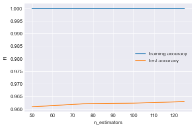

```python
PlotTrainingTestAccuracy(rfgs.cv_results_,'n_estimators')
```

Selecting n_estimators = 80

```python
#Tuning max_features
parameters = {'max_features': [4, 8, 14, 20, 24]}
rf3 = RandomForestClassifier(max_depth=20,n_estimators=80,random_state=10)
rfgs = GridSearchCV(rf3, parameters,
                    cv=5,
                   scoring="f1", return_train_score=True)
```

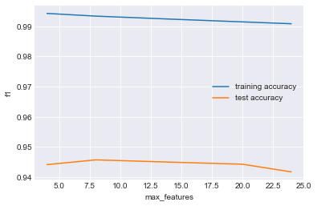

```python
rfgs.fit(X_train_pca,y_train_res)
PlotTrainingTestAccuracy(rfgs.cv_results_,'max_features')
```

```python
# Tuning min_sample_leaf
parameters = {'min_samples_leaf': range(100, 400, 50)}
rf4 = RandomForestClassifier(max_depth=20,n_estimators=80,max_features=5,random_state=10)
rfgs = GridSearchCV(rf4, parameters,
                    cv=3,
                   scoring="f1", return_train_score=True)
```

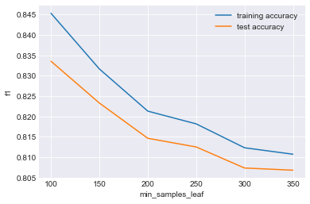

```python
rfgs.fit(X_train_pca,y_train_res)
PlotTrainingTestAccuracy(rfgs.cv_results_,'min_samples_leaf')
```

Selecting min_sample_leaf = 100

```python
#Tuning min_sample_split
parameters = {'min_samples_split': range(50, 300, 50)}
rf5 = RandomForestClassifier(max_depth=20,n_estimators=80,max_features=5,min_samples_leaf=100,random_state=10)
rfgs = GridSearchCV(rf5, parameters,
                    cv=3,
                   scoring="f1", return_train_score=True)
```

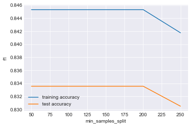

```python
rfgs.fit(X_train_pca,y_train_res)
PlotTrainingTestAccuracy(rfgs.cv_results_,'min_samples_split')
```

```python
#Tunned Randaom Forest
rf_final = RandomForestClassifier(max_depth=20,
                                  n_estimators=80,
                                  max_features=5,
                                  min_samples_leaf=100,
                                  min_samples_split=50,
                                  random_state=10)
```

```python
print("Model performance on Train data:")
ModelFit(rf_final,X_train_pca,y_train_res)
```

```
Model performance on Train data:

Model Report
Accuracy : 0.8563
Recall/Sensitivity : 0.8529
AUC Score (Train): 0.935241
CV Score : Mean - 0.9179006 , Std - 0.003089992 , Min - 0.9123647 , Max - 0.9209084
```

```python
# predict on test data
predictions = rf_final.predict(X_test_pca)
```

```python
print("Model performance on Test data:")
ModelMetrics(y_test,predictions)
```

```
Model performance on Test data:
roc_auc_score : 0.7930275048545721
Sensitivity/Recall : 0.733983286908078
Specificity: 0.8520717228010661
False Positive Rate: 0.14792827719893384
Positive predictive value: 0.301487414187643
Negative Predictive value: 0.9735603543743079
sklearn precision score value: 0.301487414187643
```

After hyperparameter tuning for the random forest. The Recall rate(Test) is 73.39%.

Let's see if we can achive a better Recall rate by deciding an optimal cut-off for the model to predict churn.

```python
# predicting churn with default cut-off 0.5
cut_off_prob=0.5
y_train_df = PredictChurnWithProbability(rf_final,X_train_pca,y_train_res,cut_off_prob)
y_train_df.head()
```

```
roc_auc_score : 0.8562701466153686
Sensitivity/Recall : 0.8529167099927212
Specificity: 0.859623583238016
False Positive Rate: 0.14037641676198398
Positive predictive value: 0.8586757393352525
Negative Predictive value: 0.8538966069307442
sklearn precision score value: 0.8586757393352525
```

|  | churn | churn_Prob | final_predicted |
| --- | --- | --- | --- |
| 0 | 0 | 0.444901 | 0 |
| 1 | 0 | 0.049022 | 0 |
| 2 | 0 | 0.256567 | 0 |
| 3 | 0 | 0.322113 | 0 |
| 4 | 0 | 0.810293 | 1 |

```
     prob  accuracy     sensi     speci
0.0   0.0  0.500000  1.000000  0.000000
0.1   0.1  0.576479  1.000000  0.152958
0.2   0.2  0.721223  0.993657  0.448789
0.3   0.3  0.807450  0.965218  0.649683
0.4   0.4  0.848887  0.916866  0.780909
0.5   0.5  0.856270  0.852917  0.859624
0.6   0.6  0.842934  0.767859  0.918010
0.7   0.7  0.800198  0.642456  0.957939
0.8   0.8  0.713866  0.444057  0.983675
0.9   0.9  0.582510  0.166944  0.998076
```

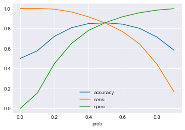

```python
# finding cut-off with the right balance of the metrices
FindOptimalCutoff(y_train_df)
```

#### From the curve above, 0.45 is the optimal point with high enough sensitivity.

```python
cut_off_prob=0.45
PredictChurnWithProbability(rf_final,X_train_pca,y_train_res,cut_off_prob)
```

```
roc_auc_score : 0.856062181553499
Sensitivity/Recall : 0.887074971404804
Specificity: 0.825049391702194
False Positive Rate: 0.17495060829780598
Positive predictive value: 0.8352670485142214
Negative Predictive value: 0.8796075605565101
sklearn precision score value: 0.8352670485142214
```

|  | churn | churn_Prob | final_predicted |
| --- | --- | --- | --- |
| 0 | 0 | 0.444901 | 0 |
| 1 | 0 | 0.049022 | 0 |
| 2 | 0 | 0.256567 | 0 |
| 3 | 0 | 0.322113 | 0 |
| 4 | 0 | 0.810293 | 1 |
| ... | ... | ... | ... |
| 38463 | 1 | 0.672480 | 1 |
| 38464 | 1 | 0.924164 | 1 |
| 38465 | 1 | 0.831023 | 1 |
| 38466 | 1 | 0.867714 | 1 |
| 38467 | 1 | 0.913246 | 1 |

38468 rows × 3 columns

#### Lets making prediction on test

```python
y_test_df= PredictChurnWithProbability(rf_final,X_test_pca,y_test,cut_off_prob)
y_test_df.head()
```

```
roc_auc_score : 0.7965333597013485
Sensitivity/Recall : 0.775766016713092
Specificity: 0.8173007026896051
False Positive Rate: 0.18269929731039497
Positive predictive value: 0.26973365617433415
Negative Predictive value: 0.9766903141740263
sklearn precision score value: 0.26973365617433415
```

|  | churn | churn_Prob | final_predicted |
| --- | --- | --- | --- |
| 4265 | 0 | 0.454218 | 1 |
| 29221 | 0 | 0.379705 | 0 |
| 974 | 0 | 0.606964 | 1 |
| 1602 | 0 | 0.382579 | 0 |
| 10225 | 0 | 0.223496 | 0 |

#### Random Forest after selecting optimal cut-off also is resulting in a model with

- Train Recall : 88.70% and Train Roc_auc_score : 85.60
- Test Recall : 77.57% and Test Roc_auc_score : 79.65

### 4. Boosting Models

#### Gradiant boosting Classifier

```python
from sklearn.ensemble import GradientBoostingClassifier  #GBM algorithm
# Fitting the default GradientBoostingClassifier
GBCModel = GradientBoostingClassifier(random_state=10)
ModelFit(GBCModel, X_train_pca, y_train_res)
```

```
Model Report
Accuracy : 0.8558
Recall/Sensitivity : 0.8601
AUC Score (Train): 0.926351
CV Score : Mean - 0.9185544 , Std - 0.003396104 , Min - 0.9128902 , Max - 0.9216971
```

```python
# Hyperparameter tuning for n_estimators
param_test1 = {'n_estimators':range(20,150,10)}
gsearch1 = GridSearchCV(estimator = GradientBoostingClassifier(learning_rate=0.1, min_samples_split=500,min_samples_leaf=50,max_depth=8,max_features='sqrt',subsample=0.8,random_state=10),
param_grid = param_test1, scoring='f1',n_jobs=4,iid=False, cv=3)
gsearch1.fit(X_train_pca, y_train_res)
```

```
GridSearchCV(cv=3, error_score=nan,
             estimator=GradientBoostingClassifier(ccp_alpha=0.0,
                                                  criterion='friedman_mse',
                                                  init=None, learning_rate=0.1,
                                                  loss='deviance', max_depth=8,
                                                  max_features='sqrt',
                                                  max_leaf_nodes=None,
                                                  min_impurity_decrease=0.0,
                                                  min_impurity_split=None,
                                                  min_samples_leaf=50,
                                                  min_samples_split=500,
                                                  min_weight_fraction_leaf=0.0,
                                                  n_estimators=100,
                                                  n_iter_no_change=None,
                                                  presort='deprecated',
                                                  random_state=10,
                                                  subsample=0.8, tol=0.0001,
                                                  validation_fraction=0.1,
                                                  verbose=0, warm_start=False),
             iid=False, n_jobs=4,
             param_grid={'n_estimators': range(20, 150, 10)},
             pre_dispatch='2*n_jobs', refit=True, return_train_score=False,
             scoring='f1', verbose=0)
```

```python
gsearch1.best_params_, gsearch1.best_score_
```

```
({'n_estimators': 140}, 0.9035607423830516)
```

```python
# Hyperparameter tuning for max_depth and min_sample_split
param_test2 = {'max_depth':range(5,16,2), 'min_samples_split':range(200,1001,200)}
gsearch2 = GridSearchCV(estimator = GradientBoostingClassifier(learning_rate=0.1, n_estimators=140, max_features='sqrt', subsample=0.8, random_state=10),
param_grid = param_test2, scoring='f1',n_jobs=4,iid=False, cv=3)
gsearch2.fit(X_train_pca, y_train_res)
```

```
GridSearchCV(cv=3, error_score=nan,
             estimator=GradientBoostingClassifier(ccp_alpha=0.0,
                                                  criterion='friedman_mse',
                                                  init=None, learning_rate=0.1,
                                                  loss='deviance', max_depth=3,
                                                  max_features='sqrt',
                                                  max_leaf_nodes=None,
                                                  min_impurity_decrease=0.0,
                                                  min_impurity_split=None,
                                                  min_samples_leaf=1,
                                                  min_samples_split=2,
                                                  min_weight_fraction_leaf=0.0,
                                                  n_estimators=140,
                                                  n_iter_no_change=None,
                                                  presort='deprecated',
                                                  random_state=10,
                                                  subsample=0.8, tol=0.0001,
                                                  validation_fraction=0.1,
                                                  verbose=0, warm_start=False),
             iid=False, n_jobs=4,
             param_grid={'max_depth': range(5, 16, 2),
                         'min_samples_split': range(200, 1001, 200)},
             pre_dispatch='2*n_jobs', refit=True, return_train_score=False,
             scoring='f1', verbose=0)
```

```python
gsearch2.best_params_, gsearch2.best_score_
```

```
({'max_depth': 15, 'min_samples_split': 200}, 0.9459475758820384)
```

```python
# Hyperparameter tuning for min_sample_leaf
param_test3 = {'min_samples_leaf':range(30,71,10)}
gsearch3 = GridSearchCV(estimator = GradientBoostingClassifier(learning_rate=0.1, n_estimators=140,max_depth=15,min_samples_split=200, max_features='sqrt', subsample=0.8, random_state=10),
param_grid = param_test3, scoring='f1',n_jobs=4,iid=False, cv=3)
gsearch3.fit(X_train_pca, y_train_res)
```

```
GridSearchCV(cv=3, error_score=nan,
             estimator=GradientBoostingClassifier(ccp_alpha=0.0,
                                                  criterion='friedman_mse',
                                                  init=None, learning_rate=0.1,
                                                  loss='deviance', max_depth=15,
                                                  max_features='sqrt',
                                                  max_leaf_nodes=None,
                                                  min_impurity_decrease=0.0,
                                                  min_impurity_split=None,
                                                  min_samples_leaf=1,
                                                  min_samples_split=200,
                                                  min_weight_fraction_leaf=0.0,
                                                  n_estimators=140,
                                                  n_iter_no_change=None,
                                                  presort='deprecated',
                                                  random_state=10,
                                                  subsample=0.8, tol=0.0001,
                                                  validation_fraction=0.1,
                                                  verbose=0, warm_start=False),
             iid=False, n_jobs=4,
             param_grid={'min_samples_leaf': range(30, 71, 10)},
             pre_dispatch='2*n_jobs', refit=True, return_train_score=False,
             scoring='f1', verbose=0)
```

```python
gsearch3.best_params_, gsearch3.best_score_
```

```
({'min_samples_leaf': 30}, 0.9446566691343824)
```

```python
# Hyperparameter tuning for max_features
param_test4 = {'max_features':range(7,20,2)}
gsearch4 = GridSearchCV(estimator = GradientBoostingClassifier(learning_rate=0.1, n_estimators=140,max_depth=15, min_samples_split=200, min_samples_leaf=30, subsample=0.8, random_state=10),
param_grid = param_test4, scoring='f1',n_jobs=4,iid=False, cv=3)
gsearch4.fit(X_train_pca, y_train_res)
```

```
GridSearchCV(cv=3, error_score=nan,
             estimator=GradientBoostingClassifier(ccp_alpha=0.0,
                                                  criterion='friedman_mse',
                                                  init=None, learning_rate=0.1,
                                                  loss='deviance', max_depth=15,
                                                  max_features=None,
                                                  max_leaf_nodes=None,
                                                  min_impurity_decrease=0.0,
                                                  min_impurity_split=None,
                                                  min_samples_leaf=30,
                                                  min_samples_split=200,
                                                  min_weight_fraction_leaf=0.0,
                                                  n_estimators=140,
                                                  n_iter_no_change=None,
                                                  presort='deprecated',
                                                  random_state=10,
                                                  subsample=0.8, tol=0.0001,
                                                  validation_fraction=0.1,
                                                  verbose=0, warm_start=False),
             iid=False, n_jobs=4, param_grid={'max_features': range(7, 20, 2)},
             pre_dispatch='2*n_jobs', refit=True, return_train_score=False,
             scoring='f1', verbose=0)
```

```python
gsearch4.best_params_, gsearch4.best_score_
```

```
({'max_features': 17}, 0.9482430996483249)
```

Tunned GradientBoostingClassifier

```python
# Tunned GradientBoostingClassifier
gbm_final = GradientBoostingClassifier(learning_rate=0.1, n_estimators=140,max_features=15,max_depth=15, min_samples_split=200, min_samples_leaf=40, subsample=0.8, random_state=10)
ModelFit(gbm_final, X_train_pca, y_train_res)
```

```
Model Report
Accuracy : 0.9998
Recall/Sensitivity : 1
AUC Score (Train): 1.000000
CV Score : Mean - 0.9871707 , Std - 0.0009849596 , Min - 0.9855042 , Max - 0.9884794
```

```python
# predictions on Test data
dtest_predictions = gbm_final.predict(X_test_pca)
```

```python
# model Performance on test data
ModelMetrics(y_test,dtest_predictions)
```

```
roc_auc_score : 0.759738166959482
Sensitivity/Recall : 0.5807799442896936
Specificity: 0.9386963896292707
False Positive Rate: 0.061303610370729344
Positive predictive value: 0.4517876489707476
Negative Predictive value: 0.9626040501925706
sklearn precision score value: 0.4517876489707476
```

Let's see if we can achive a better Recall rate by deciding an optimal cut-off for the model to predict churn.

```python
# predicting churn with default cut-off 0.5
cut_off_prob=0.5
y_train_df = PredictChurnWithProbability(gbm_final,X_train_pca,y_train_res,cut_off_prob)
y_train_df.head()
```

```
roc_auc_score : 0.9997660393053968
Sensitivity/Recall : 1.0
Specificity: 0.9995320786107934
False Positive Rate: 0.0004679213892066133
Positive predictive value: 0.9995322974588162
Negative Predictive value: 1.0
sklearn precision score value: 0.9995322974588162
```

|  | churn | churn_Prob | final_predicted |
| --- | --- | --- | --- |
| 0 | 0 | 0.020715 | 0 |
| 1 | 0 | 0.002513 | 0 |
| 2 | 0 | 0.014761 | 0 |
| 3 | 0 | 0.015672 | 0 |
| 4 | 0 | 0.251142 | 0 |

```
     prob  accuracy     sensi     speci
0.0   0.0  0.500000  1.000000  0.000000
0.1   0.1  0.965166  1.000000  0.930332
0.2   0.2  0.990122  1.000000  0.980243
0.3   0.3  0.996985  1.000000  0.993969
0.4   0.4  0.998986  1.000000  0.997972
0.5   0.5  0.999766  1.000000  0.999532
0.6   0.6  0.999896  0.999948  0.999844
0.7   0.7  0.999792  0.999584  1.000000
0.8   0.8  0.998726  0.997452  1.000000
0.9   0.9  0.984663  0.969325  1.000000
```

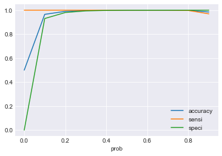

```python
FindOptimalCutoff(y_train_df)
```

```python
cut_off_prob=0.1
PredictChurnWithProbability(gbm_final,X_train_pca,y_train_res,cut_off_prob)
```

```
roc_auc_score : 0.965165852136841
Sensitivity/Recall : 1.0
Specificity: 0.9303317042736821
False Positive Rate: 0.06966829572631798
Positive predictive value: 0.9348692524545543
Negative Predictive value: 1.0
sklearn precision score value: 0.9348692524545543
```

|  | churn | churn_Prob | final_predicted |
| --- | --- | --- | --- |
| 0 | 0 | 0.020715 | 0 |
| 1 | 0 | 0.002513 | 0 |
| 2 | 0 | 0.014761 | 0 |
| 3 | 0 | 0.015672 | 0 |
| 4 | 0 | 0.251142 | 1 |
| ... | ... | ... | ... |
| 38463 | 1 | 0.993733 | 1 |
| 38464 | 1 | 0.972359 | 1 |
| 38465 | 1 | 0.981547 | 1 |
| 38466 | 1 | 0.991861 | 1 |
| 38467 | 1 | 0.985463 | 1 |

38468 rows × 3 columns

Making prediction on test

```python
y_test_df= PredictChurnWithProbability(gbm_final,X_test_pca,y_test,cut_off_prob)
y_test_df.head()
```

```
roc_auc_score : 0.8087663076161942
Sensitivity/Recall : 0.7952646239554317
Specificity: 0.8222679912769566
False Positive Rate: 0.17773200872304337
Positive predictive value: 0.2801766437684004
Negative Predictive value: 0.9788001153735217
sklearn precision score value: 0.2801766437684004
```

|  | churn | churn_Prob | final_predicted |
| --- | --- | --- | --- |
| 4265 | 0 | 0.307174 | 1 |
| 29221 | 0 | 0.056469 | 0 |
| 974 | 0 | 0.447631 | 1 |
| 1602 | 0 | 0.023201 | 0 |
| 10225 | 0 | 0.016619 | 0 |

This model is litrally over-fitting the Training data with a lower performance on the Test data.

#### XGBoost Classifier

```python
import xgboost as xgb
from xgboost.sklearn import XGBClassifier
# Fitting the XGBClassifier
xgb1 = XGBClassifier(learning_rate =0.1,
                    n_estimators=1000,
                    max_depth=5,
                    min_child_weight=1,
                    gamma=0,
                    subsample=0.8,
                    colsample_bytree=0.8,
                    objective= 'binary:logistic',
                    nthread=4,
                    scale_pos_weight=1,
                    seed=27)
```

```python
# Model fit and performance on Train data
ModelFit(xgb1, X_train_pca, y_train_res)
```

```
Model Report
Accuracy : 0.9985
Recall/Sensitivity : 0.9995
AUC Score (Train): 0.999991
CV Score : Mean - 0.9852889 , Std - 0.001094251 , Min - 0.9835717 , Max - 0.9868641
```

```python
# Hyperparameter tunning for the XGBClassifer
param_test1 = {'max_depth':range(3,10,2),'min_child_weight':range(1,6,2)}
gsearch1 = GridSearchCV(estimator = XGBClassifier( learning_rate =0.1, n_estimators=140, max_depth=5,
 min_child_weight=1, gamma=0, subsample=0.8, colsample_bytree=0.8,
 objective= 'binary:logistic', nthread=4, scale_pos_weight=1, seed=27),
 param_grid = param_test1, scoring='f1',n_jobs=4,iid=False, cv=3)
gsearch1.fit(X_train_pca, y_train_res)
```

```
GridSearchCV(cv=3, error_score=nan,
             estimator=XGBClassifier(base_score=None, booster=None,
                                     colsample_bylevel=None,
                                     colsample_bynode=None,
                                     colsample_bytree=0.8, gamma=0, gpu_id=None,
                                     importance_type='gain',
                                     interaction_constraints=None,
                                     learning_rate=0.1, max_delta_step=None,
                                     max_depth=5, min_child_weight=1,
                                     missing=nan, monotone_constraints=None,
                                     n_estimators=140, n...
                                     num_parallel_tree=None,
                                     objective='binary:logistic',
                                     random_state=None, reg_alpha=None,
                                     reg_lambda=None, scale_pos_weight=1,
                                     seed=27, subsample=0.8, tree_method=None,
                                     validate_parameters=None, verbosity=None),
             iid=False, n_jobs=4,
             param_grid={'max_depth': range(3, 10, 2),
                         'min_child_weight': range(1, 6, 2)},
             pre_dispatch='2*n_jobs', refit=True, return_train_score=False,
             scoring='f1', verbose=0)
```

```python
gsearch1.best_params_, gsearch1.best_score_
```

```
({'max_depth': 9, 'min_child_weight': 1}, 0.9445093573965541)
```

```python
# Some more hyperparameter tunning for the XGBClassifer
param_test2 = param_test3 = {'gamma':[i/10.0 for i in range(0,5)]}
gsearch2 = GridSearchCV(estimator = XGBClassifier( learning_rate=0.1, n_estimators=140, max_depth=9,
 min_child_weight=1, gamma=0, subsample=0.8, colsample_bytree=0.8,
 objective= 'binary:logistic', nthread=4, scale_pos_weight=1,seed=27),
 param_grid = param_test2, scoring='f1',n_jobs=4,iid=False, cv=3)
gsearch2.fit(X_train_pca, y_train_res)
```

```
GridSearchCV(cv=3, error_score=nan,
             estimator=XGBClassifier(base_score=None, booster=None,
                                     colsample_bylevel=None,
                                     colsample_bynode=None,
                                     colsample_bytree=0.8, gamma=0, gpu_id=None,
                                     importance_type='gain',
                                     interaction_constraints=None,
                                     learning_rate=0.1, max_delta_step=None,
                                     max_depth=9, min_child_weight=1,
                                     missing=nan, monotone_constraints=None,
                                     n_estimators=140, n...ead=4,
                                     num_parallel_tree=None,
                                     objective='binary:logistic',
                                     random_state=None, reg_alpha=None,
                                     reg_lambda=None, scale_pos_weight=1,
                                     seed=27, subsample=0.8, tree_method=None,
                                     validate_parameters=None, verbosity=None),
             iid=False, n_jobs=4,
             param_grid={'gamma': [0.0, 0.1, 0.2, 0.3, 0.4]},
             pre_dispatch='2*n_jobs', refit=True, return_train_score=False,
             scoring='f1', verbose=0)
```

```python
gsearch2.best_params_, gsearch2.best_score_
```

```
({'gamma': 0.1}, 0.9455526445452233)
```

```python
# Final XGBClassifier
xgb2 = XGBClassifier( learning_rate=0.1, n_estimators=140, max_depth=9,
 min_child_weight=1, gamma=0, subsample=0.8, colsample_bytree=0.8,
 objective= 'binary:logistic', nthread=4, scale_pos_weight=1,seed=27)
```

```python
# Fit Train data
ModelFit(xgb2, X_train_pca, y_train_res)
```

```
Model Report
Accuracy : 0.9962
Recall/Sensitivity : 0.9997
AUC Score (Train): 0.999957
CV Score : Mean - 0.9857276 , Std - 0.000926167 , Min - 0.9840054 , Max - 0.9866005
```

```python
# Prediction on Test data
dtest_predictions = xgb2.predict(X_test_pca)
```

```python
# Model evaluation on Test data
ModelMetrics(y_test,dtest_predictions)
```

```
roc_auc_score : 0.764399534825016
Sensitivity/Recall : 0.5974930362116991
Specificity: 0.931306033438333
False Positive Rate: 0.06869396656166707
Positive predictive value: 0.4307228915662651
Negative Predictive value: 0.9637662988966901
sklearn precision score value: 0.4307228915662651
```

Let's see if we can achive a better Recall rate by deciding an optimal cut-off for the model to predict churn.

```python
# predicting churn with default cut-off 0.5
cut_off_prob=0.5
y_train_df = PredictChurnWithProbability(xgb2,X_train_pca,y_train_res,cut_off_prob)
y_train_df.head()
```

```
roc_auc_score : 0.996178641988146
Sensitivity/Recall : 0.9996880524071956
Specificity: 0.9926692315690964
False Positive Rate: 0.0073307684309036085
Positive predictive value: 0.9927203262945945
Negative Predictive value: 0.9996858474265669
sklearn precision score value: 0.9927203262945945
```

|  | churn | churn_Prob | final_predicted |
| --- | --- | --- | --- |
| 0 | 0 | 0.056335 | 0 |
| 1 | 0 | 0.001047 | 0 |
| 2 | 0 | 0.074612 | 0 |
| 3 | 0 | 0.017840 | 0 |
| 4 | 0 | 0.415750 | 0 |

```
     prob  accuracy     sensi     speci
0.0   0.0  0.500000  1.000000  0.000000
0.1   0.1  0.938520  1.000000  0.877041
0.2   0.2  0.973432  1.000000  0.946865
0.3   0.3  0.986482  1.000000  0.972965
0.4   0.4  0.992669  0.999948  0.985390
0.5   0.5  0.996179  0.999688  0.992669
0.6   0.6  0.997686  0.998700  0.996673
0.7   0.7  0.996127  0.993917  0.998336
0.8   0.8  0.989472  0.979411  0.999532
0.9   0.9  0.955469  0.910939  1.000000
```

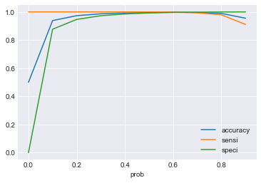

```python
# Finding optimal cut-off probability
FindOptimalCutoff(y_train_df)
```

```python
# Selecting 0.2 as cut-off in an attempt to improve recall rate
cut_off_prob=0.2
PredictChurnWithProbability(xgb2,X_train_pca,y_train_res,cut_off_prob)
```

```
roc_auc_score : 0.9734324633461579
Sensitivity/Recall : 1.0
Specificity: 0.9468649266923157
False Positive Rate: 0.05313507330768431
Positive predictive value: 0.9495458135860979
Negative Predictive value: 1.0
sklearn precision score value: 0.9495458135860979
```

|  | churn | churn_Prob | final_predicted |
| --- | --- | --- | --- |
| 0 | 0 | 0.056335 | 0 |
| 1 | 0 | 0.001047 | 0 |
| 2 | 0 | 0.074612 | 0 |
| 3 | 0 | 0.017840 | 0 |
| 4 | 0 | 0.415750 | 1 |
| ... | ... | ... | ... |
| 38463 | 1 | 0.987175 | 1 |
| 38464 | 1 | 0.965802 | 1 |
| 38465 | 1 | 0.933915 | 1 |
| 38466 | 1 | 0.988615 | 1 |
| 38467 | 1 | 0.958544 | 1 |

38468 rows × 3 columns

Making prediction on test

```python
y_test_df= PredictChurnWithProbability(xgb2,X_test_pca,y_test,cut_off_prob)
y_test_df.head()
```

```
roc_auc_score : 0.806017408289591
Sensitivity/Recall : 0.754874651810585
Specificity: 0.857160164768597
False Positive Rate: 0.14283983523140295
Positive predictive value: 0.31493317838466006
Negative Predictive value: 0.9757274858640188
sklearn precision score value: 0.31493317838466006
```

|  | churn | churn_Prob | final_predicted |
| --- | --- | --- | --- |
| 4265 | 0 | 0.559298 | 1 |
| 29221 | 0 | 0.058509 | 0 |
| 974 | 0 | 0.193681 | 0 |
| 1602 | 0 | 0.018037 | 0 |
| 10225 | 0 | 0.089590 | 0 |

### 5. SVM

```python
# instantiate an object of class SVC()
# note that we are using cost C=1
SVMModel = SVC(C = 1)
```

```python
# fit
SVMModel.fit(X_train_pca, y_train_res)

# predict on train
y_pred = SVMModel.predict(X_train_pca)
ModelMetrics(y_train_res,y_pred)
```

```
roc_auc_score : 0.8572579806592491
Sensitivity/Recall : 0.8457419153582199
Specificity: 0.8687740459602786
False Positive Rate: 0.13122595403972132
Positive predictive value: 0.8656803789047949
Negative Predictive value: 0.8492148193322153
sklearn precision score value: 0.8656803789047949
```

```python
# Predict on test
y_pred = SVMModel.predict(X_test_pca)
ModelMetrics(y_test,y_pred)
```

```
roc_auc_score : 0.8093201034292143
Sensitivity/Recall : 0.7479108635097493
Specificity: 0.8707293433486795
False Positive Rate: 0.12927065665132056
Positive predictive value: 0.334788029925187
Negative Predictive value: 0.9754343105320304
sklearn precision score value: 0.334788029925187
```

Let's see if we can tune the hyperparameters of SVM and get a better Sensitivity score.

```python
# specify range of parameters (C) as a list
params = {"C": [0.1, 1, 10, 100, 1000]}

svm1 = SVC()

# set up grid search scheme
# note that we are still using the 5 fold CV scheme
model_cv = GridSearchCV(estimator = svm1, param_grid = params,
                        scoring= 'f1',
                        cv = 5,
                        verbose = 1,
                        n_jobs=4,
                       return_train_score=True)
model_cv.fit(X_train_pca, y_train_res)
```

```
Fitting 5 folds for each of 5 candidates, totalling 25 fits
```

```
[Parallel(n_jobs=4)]: Using backend LokyBackend with 4 concurrent workers.
[Parallel(n_jobs=4)]: Done  25 out of  25 | elapsed: 21.4min finished
```

```
GridSearchCV(cv=5, error_score=nan,
             estimator=SVC(C=1.0, break_ties=False, cache_size=200,
                           class_weight=None, coef0=0.0,
                           decision_function_shape='ovr', degree=3,
                           gamma='scale', kernel='rbf', max_iter=-1,
                           probability=False, random_state=None, shrinking=True,
                           tol=0.001, verbose=False),
             iid='deprecated', n_jobs=4,
             param_grid={'C': [0.1, 1, 10, 100, 1000]}, pre_dispatch='2*n_jobs',
             refit=True, return_train_score=True, scoring='f1', verbose=1)
```

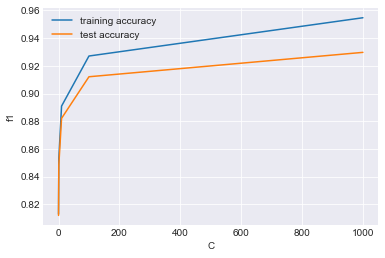

```python
PlotTrainingTestAccuracy(model_cv.cv_results_,'C')
```

```python
model_cv.best_params_
```

```
{'C': 1000}
```

```python
svm_final = SVC(C = 1000)
# fit
svm_final.fit(X_train_pca, y_train_res)
```

```
SVC(C=1000, break_ties=False, cache_size=200, class_weight=None, coef0=0.0,
    decision_function_shape='ovr', degree=3, gamma='scale', kernel='rbf',
    max_iter=-1, probability=False, random_state=None, shrinking=True,
    tol=0.001, verbose=False)
```

```python
# predict
y_pred = svm_final.predict(X_test_pca)
ModelMetrics(y_test,y_pred)
```

```
roc_auc_score : 0.7431706953259094
Sensitivity/Recall : 0.5793871866295265
Specificity: 0.9069542040222922
False Positive Rate: 0.09304579597770778
Positive predictive value: 0.35135135135135137
Negative Predictive value: 0.9612223934257833
sklearn precision score value: 0.35135135135135137
```

#### Using non-linear kernal

```python
svm_k = SVC(C = 1000, kernel='rbf')
svm_k.fit(X_train_pca, y_train_res)
```

```
SVC(C=1000, break_ties=False, cache_size=200, class_weight=None, coef0=0.0,
    decision_function_shape='ovr', degree=3, gamma='scale', kernel='rbf',
    max_iter=-1, probability=False, random_state=None, shrinking=True,
    tol=0.001, verbose=False)
```

```python
y_pred = svm_k.predict(X_test_pca)
ModelMetrics(y_test,y_pred)
```

```
roc_auc_score : 0.7431706953259094
Sensitivity/Recall : 0.5793871866295265
Specificity: 0.9069542040222922
False Positive Rate: 0.09304579597770778
Positive predictive value: 0.35135135135135137
Negative Predictive value: 0.9612223934257833
sklearn precision score value: 0.35135135135135137
```

#### Recall : 57%

Lets compare and decide a model of choice for this problem of churn prediction.

### Choose the best Model

#### Recall is the most important business metric for the telecom churn problem. The company would like to identify most customers at risk of churning, even if there are many customers that are misclassified as churn. The cost to the company of churning is much higher than having a few false positives.

| Model/Metrics | Train | Test |  | Model/Metrics | Train | Test |
| --- | --- | --- | --- | --- | --- | --- |
| **Logistic Regression(cut-off=0.45)** |  |  |  | **DecisionTree ( cut-off = 0.4)** |  |  |
| Roc_auc_score | 82.12% | 81.21% |  | Roc_auc_score | 82.40% | 76.56% |
| Sensitivity/Recall | 86.48% | 84.40% |  | Sensitivity/Recall | 89.78% | 78.13% |
| Specificity | 77.76% | 78.03% |  | Specificity | 75.02% | 76.01% |
| precision | 79.54% | 25.05% |  | precision | 78.24% | 21.38% |

| Model/Metrics | Train | Test |  | Model/Metrics | Train | Test |
| --- | --- | --- | --- | --- | --- | --- |
| **Random Forest(cut-off=0.45)** |  |  |  | **GBC ( cut-off = 0.1)** |  |  |
| Roc_auc_score | 85.61% | 79.65% |  | Roc_auc_score | 96.52% | 80.88% |
| Sensitivity/Recall | 88.71% | 77.57% |  | Sensitivity/Recall | 100% | 79.53% |
| Specificity | 82.50% | 81.73% |  | Specificity | 93.03% | 82.23% |
| precision | 83.53% | 26.97% |  | precision | 93.49% | 28.02% |

[output not shown]

### Get relevant churn features.

We will use an instance of Random Forest classifier to identify the features most relevant to churn.

### Random Forest for churn driver features

```python
# Create the parameter grid based on the results of random search
param_grid = {
    'max_depth': [8,10,12],
    'min_samples_leaf': range(100, 400, 200),
    'min_samples_split': range(200, 500, 200),
    'n_estimators': [100,200, 300],
    'max_features': [12, 15, 20]
}
# Create a based model
rf = RandomForestClassifier()
# Instantiate the grid search model
grid_search = GridSearchCV(estimator = rf, param_grid = param_grid,
                          cv = 3, n_jobs = 4,verbose = 1)
```

```python
# Fit the grid search to the data
grid_search.fit(X_train_res, y_train_res)
```

```
Fitting 3 folds for each of 108 candidates, totalling 324 fits
```

```
[Parallel(n_jobs=4)]: Using backend LokyBackend with 4 concurrent workers.
[Parallel(n_jobs=4)]: Done  42 tasks      | elapsed:  5.4min
[Parallel(n_jobs=4)]: Done 192 tasks      | elapsed: 29.8min
[Parallel(n_jobs=4)]: Done 324 out of 324 | elapsed: 53.1min finished
```

```
GridSearchCV(cv=3, error_score=nan,
             estimator=RandomForestClassifier(bootstrap=True, ccp_alpha=0.0,
                                              class_weight=None,
                                              criterion='gini', max_depth=None,
                                              max_features='auto',
                                              max_leaf_nodes=None,
                                              max_samples=None,
                                              min_impurity_decrease=0.0,
                                              min_impurity_split=None,
                                              min_samples_leaf=1,
                                              min_samples_split=2,
                                              min_weight_fraction_leaf=0.0,
                                              n_estimators=100, n_jobs=None,
                                              oob_score=False,
                                              random_state=None, verbose=0,
                                              warm_start=False),
             iid='deprecated', n_jobs=4,
             param_grid={'max_depth': [8, 10, 12], 'max_features': [12, 15, 20],
                         'min_samples_leaf': range(100, 400, 200),
                         'min_samples_split': range(200, 500, 200),
                         'n_estimators': [100, 200, 300]},
             pre_dispatch='2*n_jobs', refit=True, return_train_score=False,
             scoring=None, verbose=1)
```

```python
# printing the optimal accuracy score and hyperparameters
print('We can get accuracy of',grid_search.best_score_,'using',grid_search.best_params_)
```

```
We can get accuracy of 0.8910004206025398 using {'max_depth': 12, 'max_features': 20, 'min_samples_leaf': 100, 'min_samples_split': 200, 'n_estimators': 300}
```

```python
rf = RandomForestClassifier(max_depth=12,
                            max_features=20,
                            min_samples_leaf=100,
                            min_samples_split=200,
                            n_estimators=300,
                            random_state=10)
```

```python
rf.fit(X_train_res, y_train_res)
```

```
RandomForestClassifier(bootstrap=True, ccp_alpha=0.0, class_weight=None,
                       criterion='gini', max_depth=12, max_features=20,
                       max_leaf_nodes=None, max_samples=None,
                       min_impurity_decrease=0.0, min_impurity_split=None,
                       min_samples_leaf=100, min_samples_split=200,
                       min_weight_fraction_leaf=0.0, n_estimators=300,
                       n_jobs=None, oob_score=False, random_state=10, verbose=0,
                       warm_start=False)
```

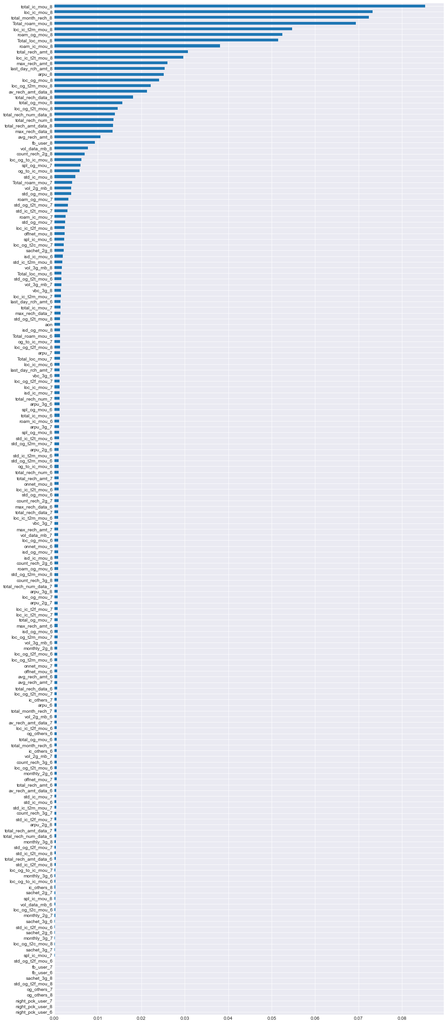

```python
plt.figure(figsize=(15,40))
feat_importances = pd.Series(rf.feature_importances_, index=X.columns)
feat_importances.nlargest(len(X.columns)).sort_values().plot(kind='barh', align='center')
```

Some of the top main predictiors of churn are the monthly KPI features for the action phase (3rd month August).

- The graph above suggest that the top 25 features ranked in order of importance as produced by our RandomForest implementation are the features that belong to month 8 i.e., the action month. It is clear that what happens in the action phase has a direct impact on the customer churn of high value customers.

Local calls Mou's be it incoming or outgoing have a very important role for churn predictions. Reduction in these KPI's forms a clear indicator of churn.

Overall, drop in any of these indicator KPI is a signal that the customer is not actively engaging in the services offered by the Network operator and thus may choose to churn in the near future.

Next, we will look at some of the stratergic steps which can be taken to retain these predicted churners.

### Strategies to manage customer churn

From the Case study description, it is a fact that it costs 5-10 times more to acquire a new customer than to retain an existing one, customer retention has now become even more important than customer acquisition.

For many incumbent operators, retaining high profitable customers is the number one business goal.

#### Monitoring Drop in usage

- Customer churn seems to be well predicted by drop in usage.
- Aside from using the Machine Learning model for predicting churn, the telecom company should pay close attention to drop in MoU, ARPU and data usage (2g and 3g) month over month.
- If feasible, the company should track these numbers week over week. Since billing cycles are typically monthly, a drop in usage numbers will give the company time to react when tracked at weekly level.
- Contact these customers proactively to find out what's affecting their experience. Perhaps, offer them coupons or other incentives to continue to use the services, while the company fixes the issues reported.
- Marketing team must come up with campaigns which targets these high-value to-be churner.

#### Improving Outgoing services

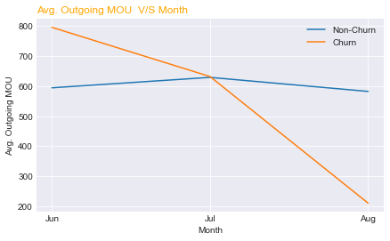

```python
# Outgoing Mou
plot_byChurnMou(og_col,'Outgoing')
```

- Initially, churner's outgoing usage was more than that of non-churners. Gradually they dropped there outgoing usage. May be these customers did not like the outgoing services offered to them or may be the call tariffs seemed expensive to them or may be the overall call quality, network coverage was not liked my them. This could be further investigated by the network service provider.

#### Stratergy suggestions,

- The Network operators must futher investigate their outgoing tariffs, plans and campaigns.
- Might be that the outgoing tariffs offered to it's customer are less competitive to the outgoing tariffs of their competitor.
- New campaigns which targets the customers with high outgoing usage be rolled out.Like,
  - Discounted outgoing rates during particular hours of the day for these customers.
  - For every X mou, grant customer with some % of X free mou.
  - Investigate and if need be revise the outgoing tarrifs to make it competitive.
  - Free monthly outgoing mou's depending on the users past roaming mou usage.

#### Improving Roaming services

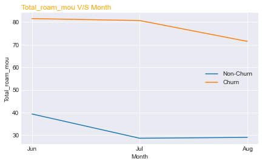

| churn | Total_roam_mou_6 | Total_roam_mou_7 | Total_roam_mou_8 |
| --- | --- | --- | --- |
| 0 | 39.360033 | 28.643301 | 29.016734 |
| 1 | 81.504156 | 80.651973 | 71.443623 |

```python
plot_byChurn(hv_users,'Total_roam_mou')
```

#### Stratergy suggestions,

- Churners show higher roaming usage than non-churners.
- The Network operators must futher investigate their roaming tariffs, and quality of service.
- Might be that the roaming tariffs offered are less competitive than their competitor.
- It might be that the customer is not getting good quality of service while roaming. In this case, quality of service guarantees with roaming partners and network quality need to be investigated.
- New campaigns which targets the roaming customers can be rolled out. Like,
  - Discounted roaming rates during particular hours of the day.
  - Free monthly roaming mou's depending on the users past roaming mou usage.